# Assignment - Partitioning and hierarchical clustering

#### Performing hierarchical clustering using ‘ward.D’ method. (Using the reduced size data)

```r
hclust_d <- hclust(
  d = dist_d,
  method = 'ward.D'
)
plot(hclust_d)
rect.hclust(hclust_d , k = 2, border = 2:6)
```

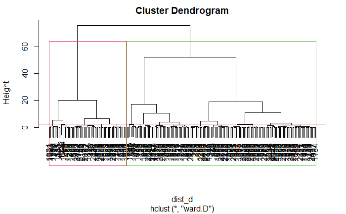

```r
abline(h = 2.5, col = 'red')
```

```r
#coefficient for clustering
coef(hclust_d)
```

```
[1] 0.998333
```

Using Silhouette plots to evaluate how well each point fits with the rest of its cluster. (Using the reduced sized data)

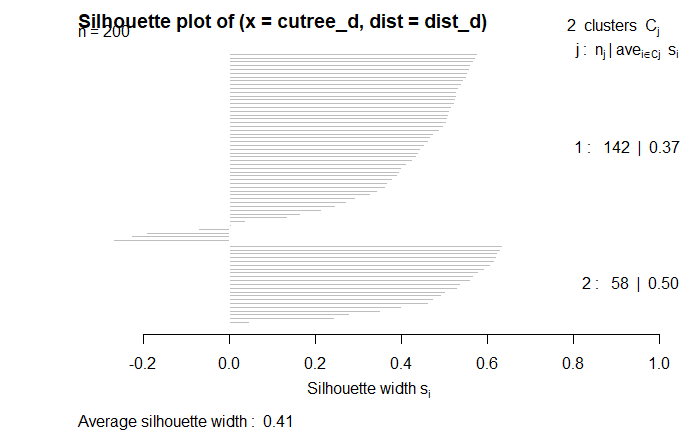

```r
cutree_d <- cutree(
  tree = hclust_d,
  k = 2
)

silhouette_d <- cluster::silhouette(
  x = cutree_d,
  dist = dist_d
)
plot(
  x = silhouette_d
)
```

#### Performing hierarchical clustering using ‘ward.D2’ method. (Using the reduced size data)

```r
hclust_d <- hclust(
  d = dist_d,
  method = 'ward.D2'
)
plot(hclust_d)
rect.hclust(hclust_d , k = 2, border = 2:6)
```

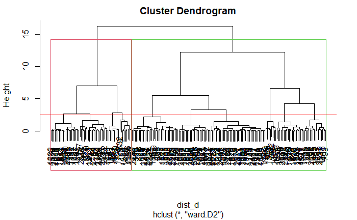

```r
abline(h = 2.5, col = 'red')
```

```r
#coefficient for clustering
coef(hclust_d)
```

```
[1] 0.9925677
```

Using Silhouette plots to evaluate how well each point fits with the rest of its cluster. (Using the reduced sized data)

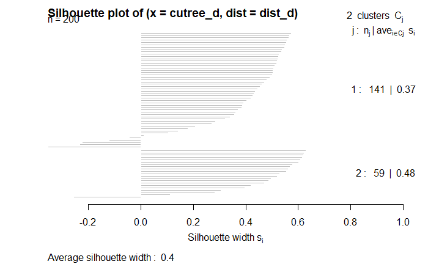

```r
cutree_d <- cutree(
  tree = hclust_d,
  k = 2
)

silhouette_d <- cluster::silhouette(
  x = cutree_d,
  dist = dist_d
)
plot(
  x = silhouette_d
)
```

#### Performing hierarchical clustering using ‘complete’ method. (Using the reduced size data)

```r
hclust_d <- hclust(
  d = dist_d,
  method = 'complete'
)
plot(hclust_d)
rect.hclust(hclust_d , k = 2, border = 2:6)
```

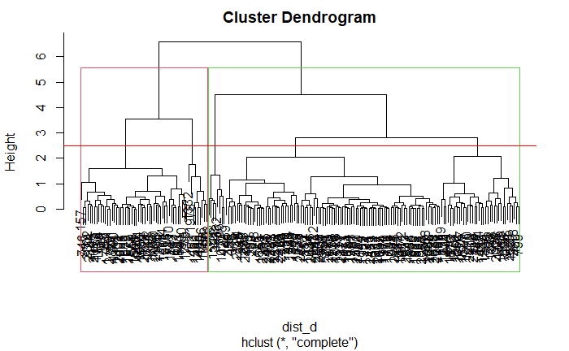

```r
abline(h = 2.5, col = 'red')
```

```r
#coefficient for clustering
coef(hclust_d)
```

```
[1] 0.9814676
```

Using Silhouette plots to evaluate how well each point fits with the rest of its cluster. (Using the reduced sized data)

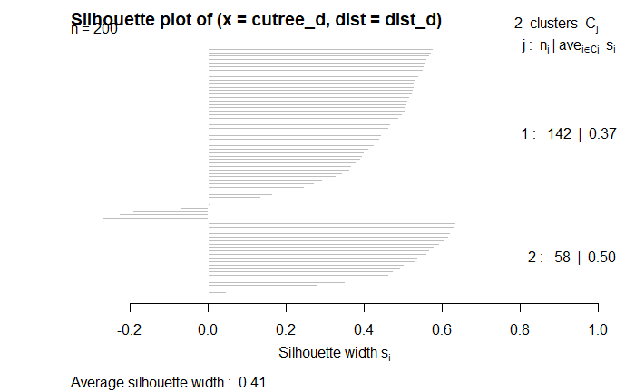

```r
cutree_d <- cutree(
  tree = hclust_d,
  k = 2
)

silhouette_d <- cluster::silhouette(
  x = cutree_d,
  dist = dist_d
)
plot(
  x = silhouette_d
)
```